# Red wine analysis

Exploratory data analysis of the red wine dataset has been conducted and the insights have been reported. The dataset holds information about the red vairent of the Portuguese “Vinho Verde” wine.

# Univariate Plots Section

The data has been loaded into the dataframe red.wine. It contains 1599 observations with 13 variables.

The various variables present in the dataframe can be found below

```
##  [1] "X"                    "fixed.acidity"        "volatile.acidity"
##  [4] "citric.acid"          "residual.sugar"       "chlorides"
##  [7] "free.sulfur.dioxide"  "total.sulfur.dioxide" "density"
## [10] "pH"                   "sulphates"            "alcohol"
## [13] "quality"
```

Let us look into these variables using plots.

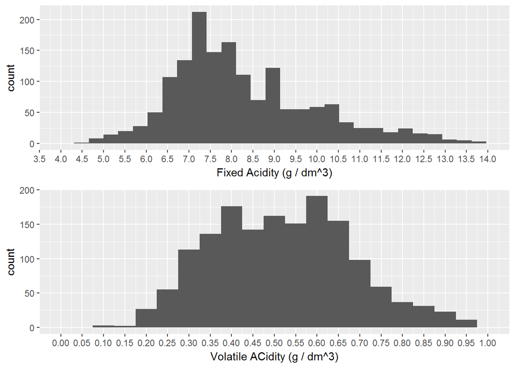

The fixed.acidity measures the quantity of non volatile acids in the wine while the variable volatile.acidity measures the amount of volatile acids.Looking at the plots of the two variables above it is clear that most red wines from the dataset have a fixed acidity between 6 and 10.5 g / dm^3 and voltaile acidity between 0.25 and 0.75 g/dm^3. The graphs almost follows the shape of a normal distribution.

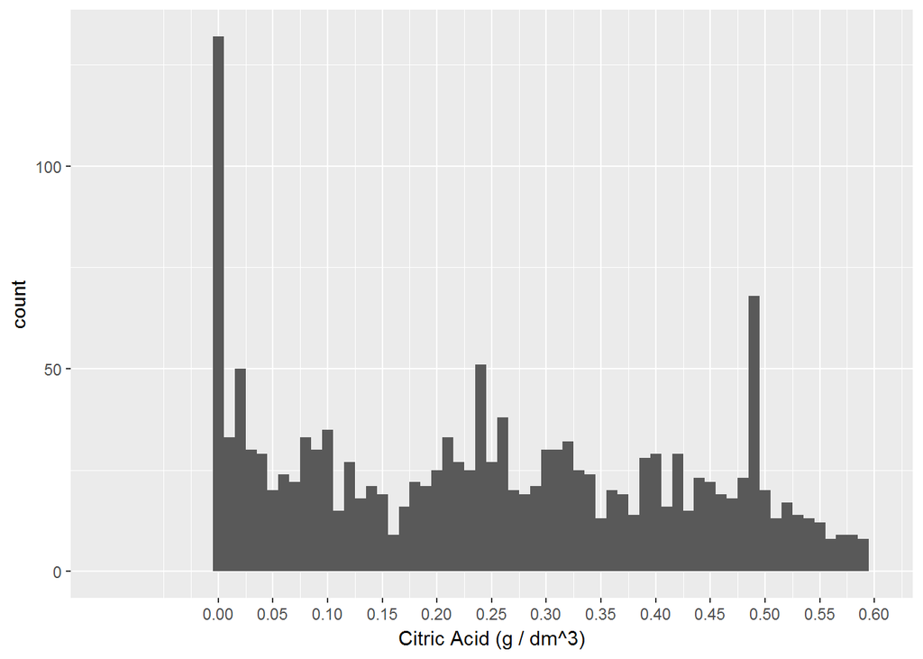

The citric acid plot reveals a sharp peak at the start where the amount is less than 0.02 g/dm^3. There occurs another peak at around 0.5 g/dm^3 where the count exceeds 50.

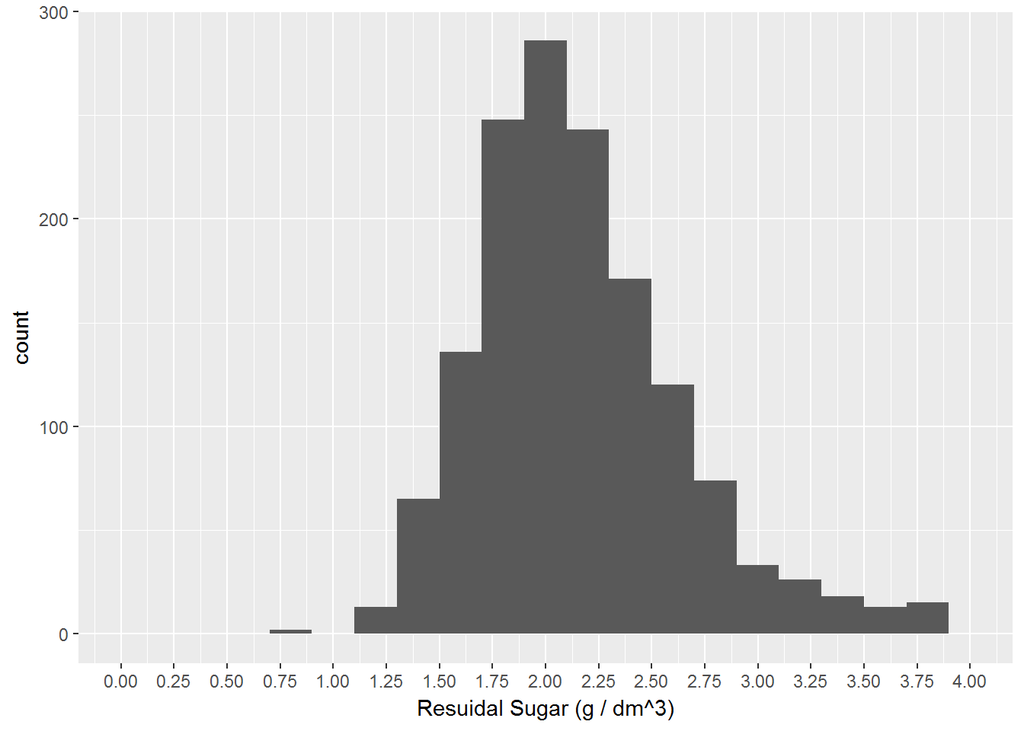